# Personal Savings Analysis

Andrew Brown, Melissa Hooke, Frances Hung, Mai Nguyen, Brenner Ryan

12/19/2018

# Time Series Exploration

The original time series, as pulled from DataMarket (https://datamarket.com/), spans 26 years of personal savings as percent of disposible income in the United States. Each year of the time series is divided into financial quarters, amounting to 104 total observations, which we plot in the time series below:

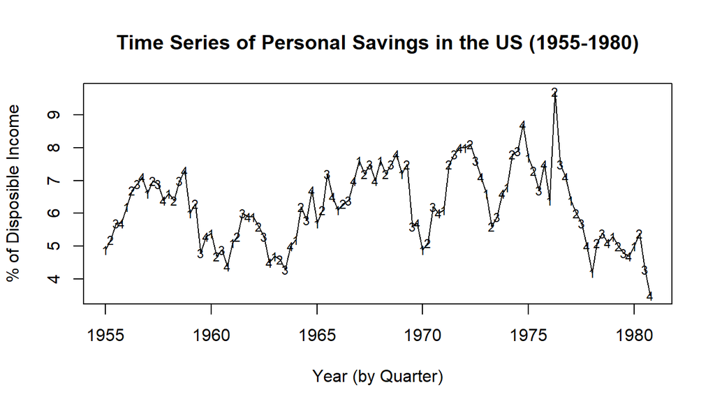

From our original time series plot, we see that there is a general upward trend with some sudden volatility in the 1970s that may be linked to the economic crash in the early 70s and oil energy crisis in 1979. Since the 1970s were marked by high inflation and growing expenses due to rising interest rates, we made the decision to remove the last 5 years of the time sereies since they would likely follow a different time series trend than the rest of the data.

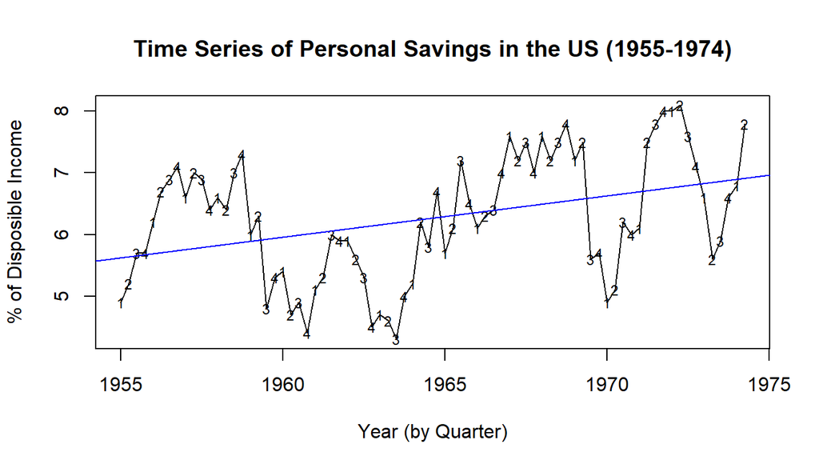

In the time series, we see a general upward trend in the data, which indicates that the time series may not be stationary and we may want to consider taking the first difference of the data. Also, while do not see any seasonal trends, given that the data is divided into financial quarters we may want to consider the possibility of taking a seasonal difference to make our time series stationary. First, however, let’s explore without taking the difference.

The first step in analyzing our time series is to consider the possible need for a transformation to stabilize the variance of the series over time. In order to do this, we use the function to determine the appropriate power transformation for time-series data.

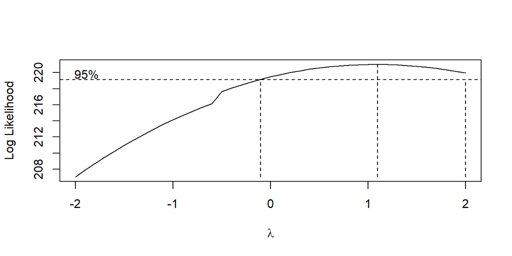

```
## [1] 1.1
```

The Boxcox output indicates that a transformation is not necessary in order to stabilize the variance since $\lambda$ is about equal to 1. Therefore, we proceed by examining the acf and pacf of the series.

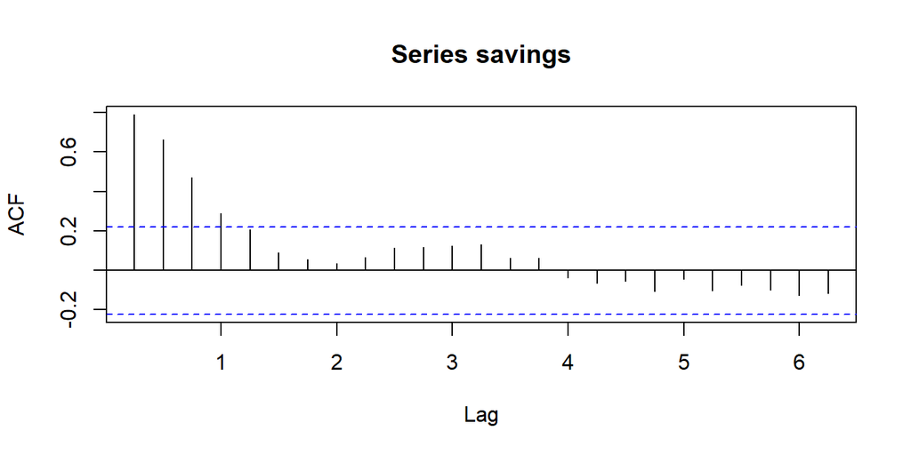

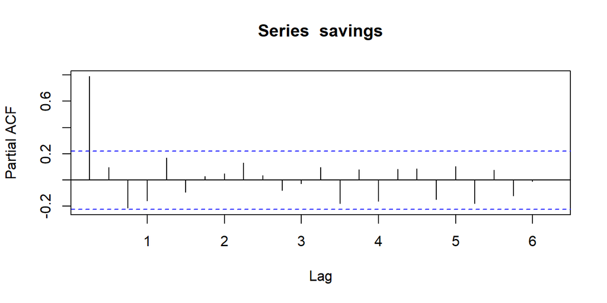

The PACF seems to indicate that an AR(1) process may be a good candidate model because the only non-zero sample partial autocorrelation is at lag $k=1$. For lags $k \geq 1$, the partial autocorrelations appear to reduce to white-noise.

Next, we consider the differenced time series, which is plotted below:

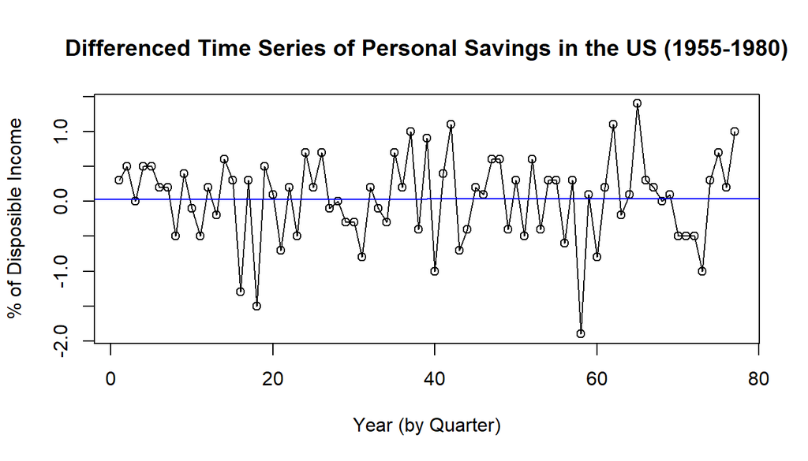

The plot of the first difference of our time series indicates that the upward trend in the data has been removed and the mean of the differenced series is about equal to zero.

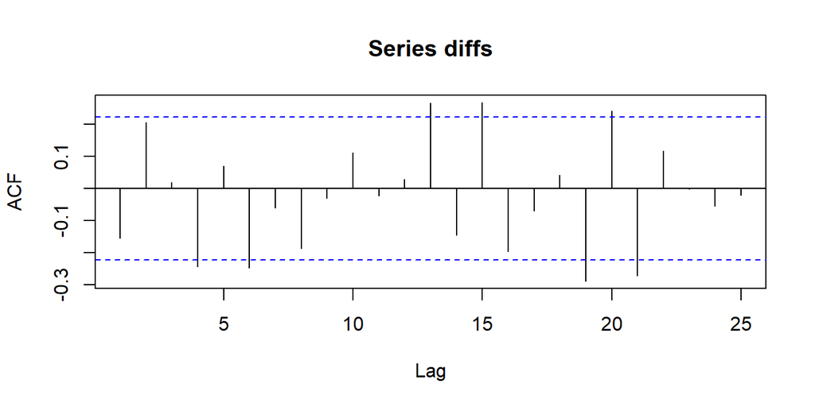

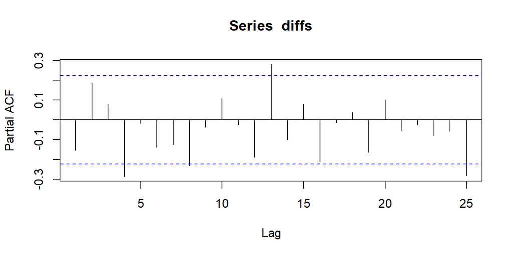

The ACF and PACF of the differenced series appear to suggest a seasonal trend in the differenced series, however, the period of this trend is unclear.

# Model Specification

Based on the preliminary explorations of our original time series and the differenced series, the candidate models are have in mind are an AR(1) process or some type of seasonal model (period 4?) based on either the original or differenced series.

In order to validate these candidate models and determine the period of possible seasonal trends, we turn to the EACF and the best subsets methods.

```
## AR/MA
##   0 1 2 3 4 5 6 7 8 9 10 11 12 13
## 0 x x x x o o o o o o o  o  o  o
## 1 o x o o o o o o o o o  o  o  o
## 2 x x o o o o o o o o o  o  o  o
## 3 x x o o o o o o o o o  o  o  o
## 4 x o o o o o o o o o o  o  o  o
## 5 x x o o o o o x o o o  o  o  o
## 6 x o o o o o o o o o o  o  o  o
## 7 x o o o o o o o o o o  o  o  o
```

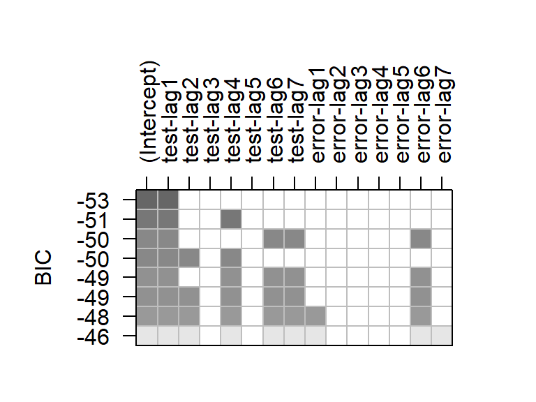

While the EACF for the original (non-differenced) time series is inconclusive, the best subsets method indicates that, an AR(1) process or a multiplicative $AR(1) \times AR(1)_4$ with a seasonal period of 4 are good candidate models.

```
## AR/MA
##   0 1 2 3 4 5 6 7 8 9 10 11 12 13
## 0 o o o x o x o o o o o  o  x  o
## 1 x o o x o o o o o o o  o  o  o
## 2 x x o x o o o o o o o  o  o  o
## 3 x x o o o o o o o o o  o  o  o
## 4 o x o o o o o x o o o  o  o  o
## 5 o x o o o o o o o o o  o  o  o
## 6 x x o o o o o o o o o  o  o  o
## 7 x o x o o o o o o o o  o  o  o
```

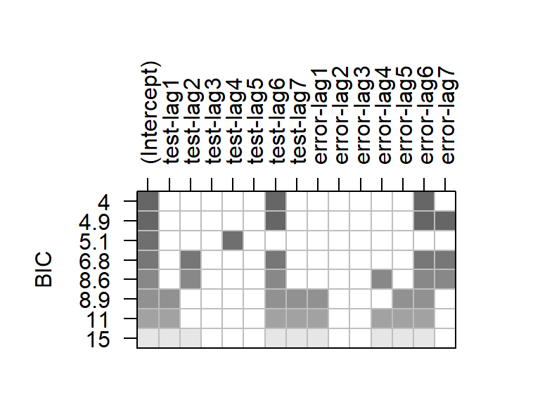

For the differenced series, a seasonal trend of 6 is suggested.

# Model Fitting

Given the results in the previous section, we have decided to fit and compare 3 different models: an AR(1), a multiplicative $AR(1) \times AR(1)_4$, and an $ARIMA(0,1,0) \times ARIMA(1,0,1)_6$ model. The parameters for each model are given in the table below:

```r
table = matrix(c("Model", 'Intercept', 'se', 'ar1', 'se', 'sar1', 'se', 'sma1', 'se',
          'AR(1)', '6.28','0.35','.83','0.07', 'x','x','x','x',
         'AR(1)XSAR(1)4', '6.27','0.35','0.86','0.06','-0.28','0.12','x','x',
         '','x','x','x','x','-0.18','0.38','-0.08','0.38'),
          nrow=9, ncol=4)
kable(table)
```

| Model | AR(1) | AR(1)XSAR(1)4 |  |
| --- | --- | --- | --- |
| Intercept | 6.28 | 6.27 | x |
| se | 0.35 | 0.35 | x |
| ar1 | .83 | 0.86 | x |
| se | 0.07 | 0.06 | x |
| sar1 | x | -0.28 | -0.18 |
| se | x | 0.12 | 0.38 |
| sma1 | x | x | -0.08 |
| se | x | x | 0.38 |

The AR(1) model is $Y_t-6.28 = .825(Y_{t-1}-6.28) + e_t$.

# Diagnostics

## AR(1)

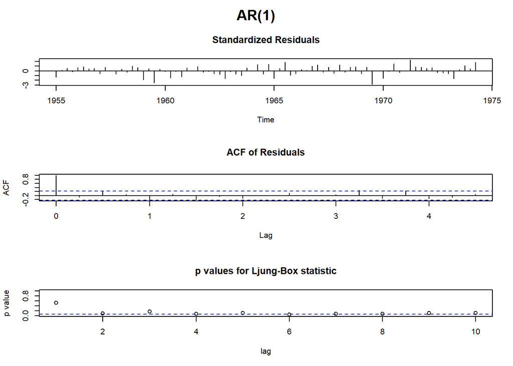

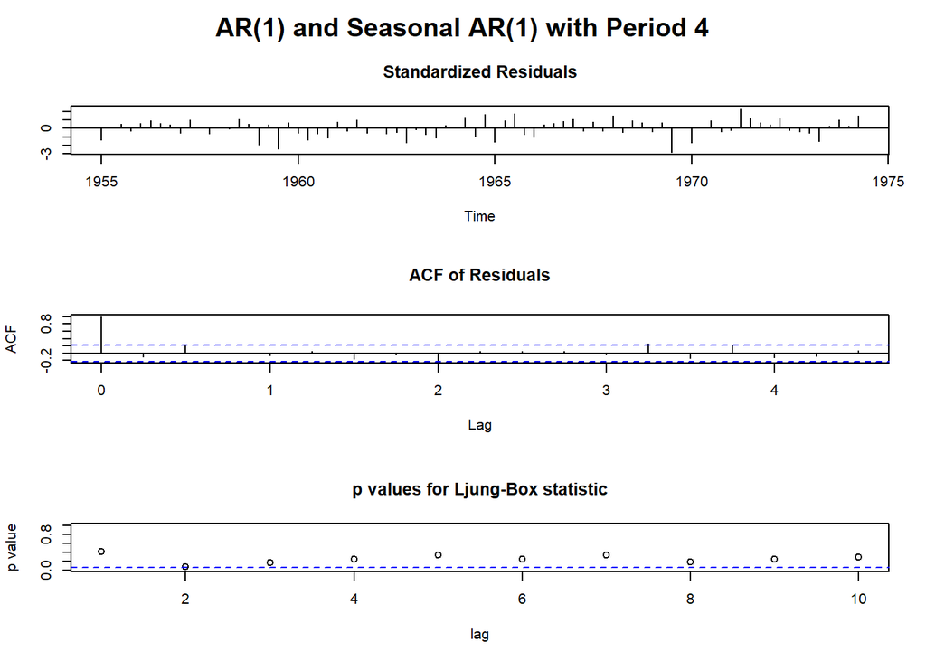

```r
par(oma=c(0,0,2,0))
tsdiag(SAR4model)
title("AR(1) and Seasonal AR(1) with Period 4", outer = TRUE)
```

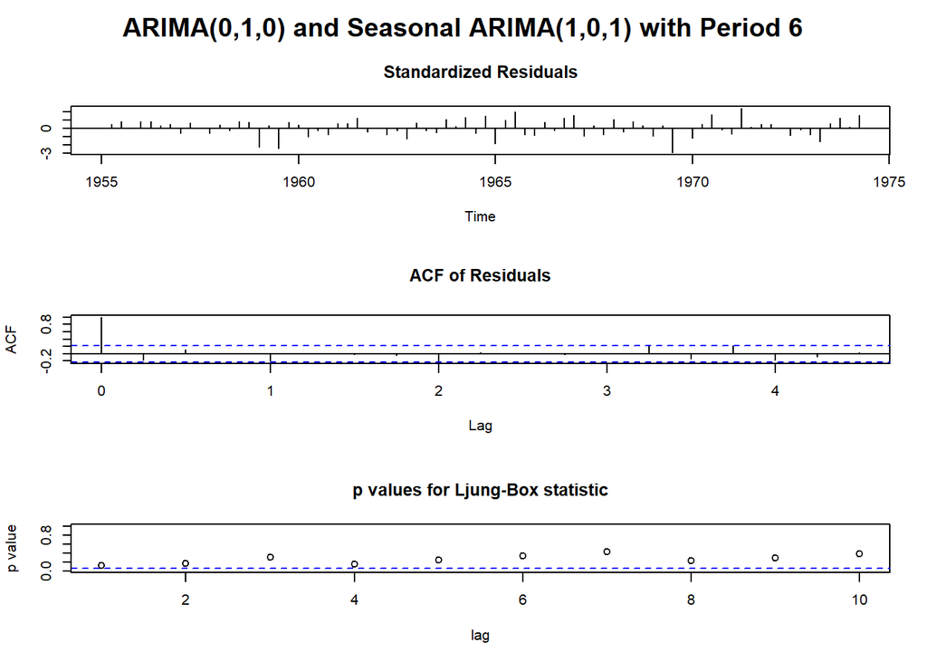

```r
par(oma=c(0,0,2,0))
tsdiag(SAR6model)
title("ARIMA(0,1,0) and Seasonal ARIMA(1,0,1) with Period 6", outer = TRUE)
```

The residuals for the $ARIMA(0,1,0) \times ARIMA(1,0,1)_6$ model resemble a white-noise process, the ACF shows no correlation patterns between residuals, and the Ljung-Box statistic is not significant for all tested lags.

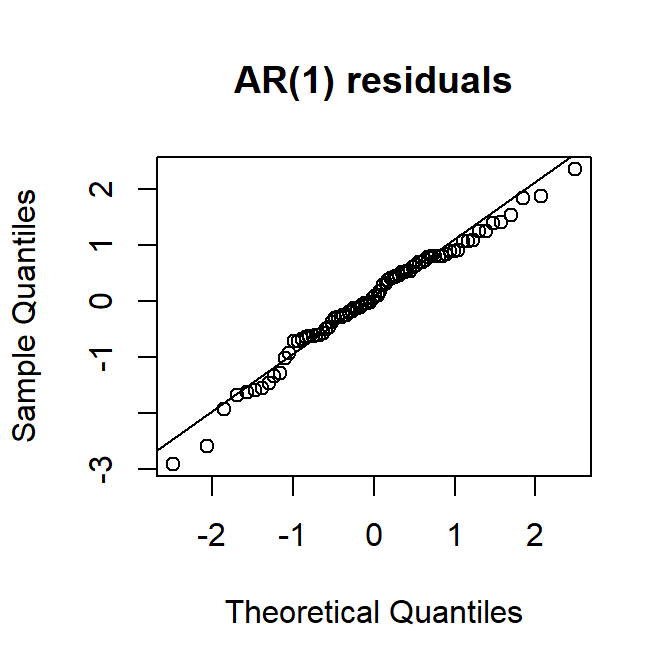

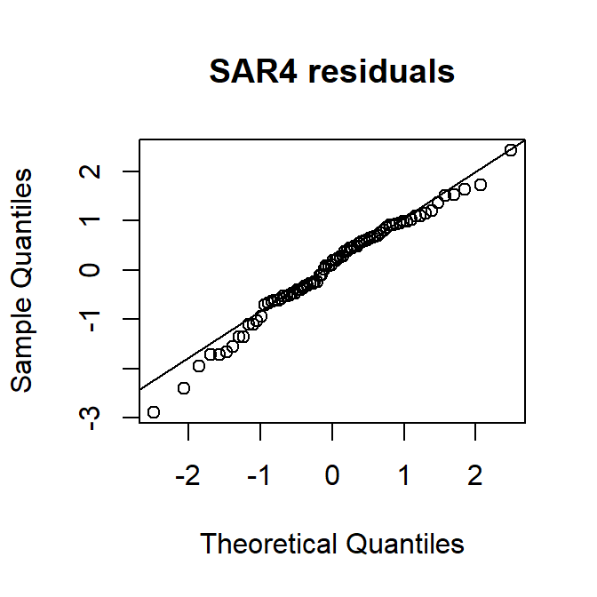

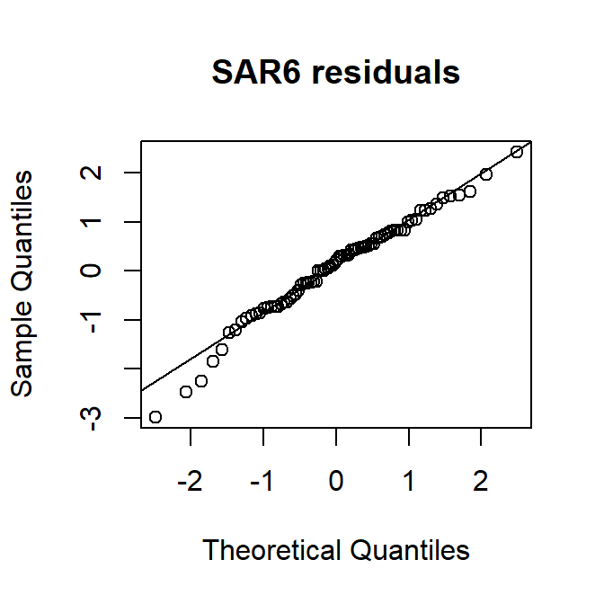

```
##
##  Shapiro-Wilk normality test
##
## data:  ARresids
## W = 0.98097, p-value = 0.2951
```

```
##
##  Shapiro-Wilk normality test
##
## data:  SAR4resids
## W = 0.98267, p-value = 0.3691
```

```
##
##  Shapiro-Wilk normality test
##
## data:  SAR6resids
## W = 0.97936, p-value = 0.2368
```

Based on their Q-Q plots and their Shapiro-Wilk tests, all models don’t show evidence of residual nonnormality.

AR(1)

```r
# test the residuals for independence
runs(ARresids)
```

[output not shown]

SAR4

```r
runs(SAR4resids)
```

[output not shown]

SAR6

```r
runs(SAR6resids)
```

[output not shown]

```r
table = cbind(c("p-value","Observed runs","Expected runs", "n1","n2","k"),
              c(0.73, 42, 29.97, 38, 40, 0),
              c(0.37,44,39.59,35,43,0),
              c(0.18,45,38.74,32,46,0))
colnames(table) = c("Runs Test","AR(1)","Seasonal 4","Seasonal 6")
kable(table)
```

[output not shown]

# Forecasting

```
## $pred
##          Qtr1     Qtr2     Qtr3     Qtr4
## 1974                   7.533497 7.313623
## 1975 7.132218 6.982552 6.859072 6.757196
##
## $se
##           Qtr1      Qtr2      Qtr3      Qtr4
## 1974                     0.5796561 0.7514738
## 1975 0.8487602 0.9090457 0.9478906 0.9734455
```

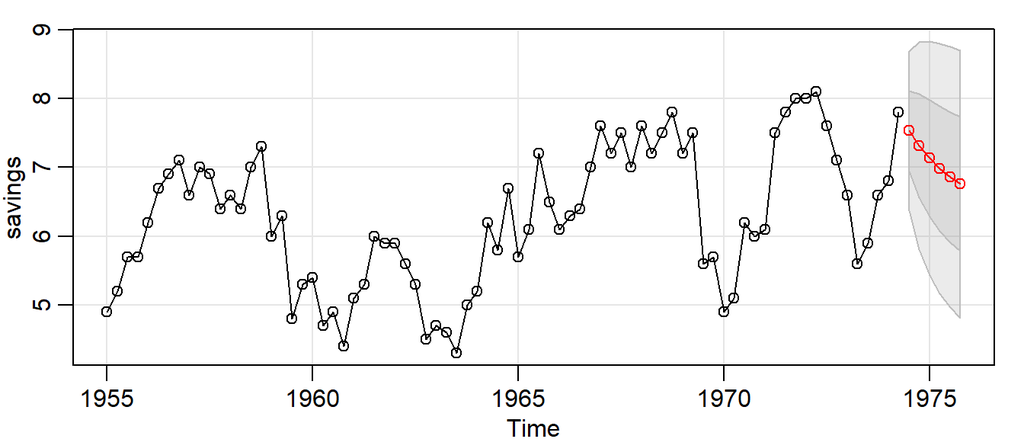

```
## $pred
##          Qtr1     Qtr2     Qtr3     Qtr4
## 1974                   7.540401 7.216360
## 1975 7.029013 6.679309 6.633252 6.616476
##
## $se
##           Qtr1      Qtr2      Qtr3      Qtr4
## 1974                     0.5654719 0.7461892
## 1975 0.8558728 0.9288601 0.9465329 0.9594238
```

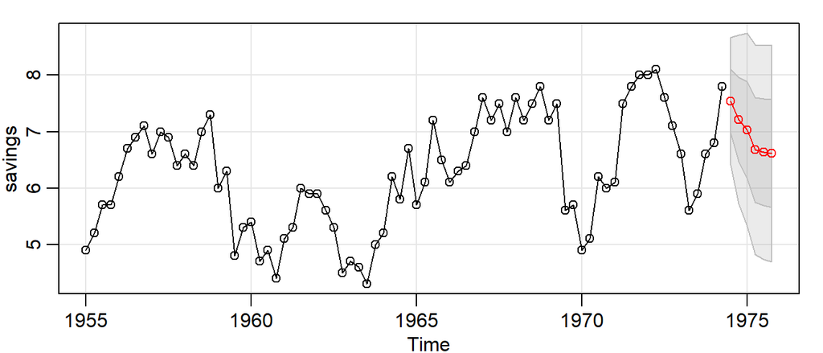

```
## $pred
##          Qtr1     Qtr2     Qtr3     Qtr4
## 1974                   7.967863 8.269178
## 1975 8.227219 8.078950 8.077971 7.860737
##
## $se
##           Qtr1      Qtr2      Qtr3      Qtr4
## 1974                     0.5819161 0.8229537
## 1975 1.0079083 1.1638322 1.3012040 1.4253975
```

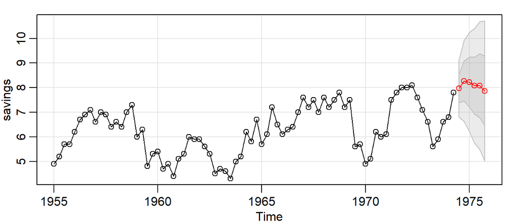

# Appendix: R Code

```r
# load the time series
savings = read.csv("savings.csv",header=TRUE, nrows=104)
savings = savings %>% select(2)
savings.entire = savings[1:84,]
savings<-ts(savings, start=c(1955),frequency=4)

# plot the original time series
plot(savings, xlab="Year (by Quarter)",
     ylab= "% of Disposible Income",
     main= "Time Series of Personal Savings in the US (1955-1980)")
points(y=savings,x=as.vector(time(savings)),pch=as.vector(season(savings)), cex=.75)
```

```r
# set aside points to validate our forecasts
savings.test = savings[79:84,]

# remove the last 5 years because of the huge dip due to recession
savings = savings[1:78,]
savings<-ts(savings, start=c(1955),frequency=4)

# plot the shortened time series with labels for quarters
plot(savings, xlab="Year (by Quarter)",
     ylab= "% of Disposible Income",
     main= "Time Series of Personal Savings in the US (1955-1980)")
points(y=savings,x=as.vector(time(savings)),pch=as.vector(season(savings)), cex=.75)
abline(lm(savings~time(savings)), col='blue')
```

```r
# should we do a transformation?
boxcox = BoxCox.ar(savings)
boxcox
boxcox$mle
```

```r
# plot the acf and pacf of the original series
acf(savings, lag.max = 25)
pacf(savings, lag.max = 25)
```

```r
# calculate the differenced time series
diffs = (savings-zlag(savings))[2:78]

# plot the differenced time series
plot(diffs, xlab="Year (by Quarter)",
     ylab= "% of Disposible Income",
     main= "Differenced Time Series of Personal Savings in the US (1955-1980)", type="o")
abline(lm(diffs~time(diffs)), col="blue")
```

```r
# plot the acf and pacf of the differenced time series
acf(diffs, lag.max = 25)
pacf(diffs, lag.max = 25)
```

```r
# use the eacf and best subsets to find a candidate model
eacf(savings)
sub = armasubsets(y=savings,nar=7,nma=7, y.name='test', ar.method='ols')
plot(sub)
```

```r
# plot the eacf and best subsets for the differenced series
eacf(diffs)
sub = armasubsets(y=diffs,nar=7,nma=7, y.name='test', ar.method='ols')
plot(sub)
```

```r
# fit an AR(1) process
AR1model = arima(savings, order = c(1, 0, 0), seasonal = list(order = c(0, 0, 0)), method=c('ML'))
AR1model
```

```r
# run some general diagnostics on the models
tsdiag(AR1model)
tsdiag(SAR4model)
tsdiag(SAR6model)
```

```r
# test the residuals for normality
shapiro.test(ARresids)
shapiro.test(SAR4resids)
shapiro.test(SAR6resids)
```

```r
# test the residuals for independence
runs(ARresids)
runs(SAR4resids)
runs(SAR6resids)
```